# Spatial Autocorrelation & Heteroscedasticity

Yalin Yang

2020-05-04

# 1 Maximum Likelihood

## 1.1 Evaluate the likelihood and log-likelhood functions

The following code-chunks evaluate the likelihood function $L(\pi \mid x,n)=\pi^x \cdot (1-\pi)^{n-x}$ and the log-likelihood function of a binary distributed outcomes $x_i \in \{0,1\}$.

Set up the model:

```r
> pi <- 1:99/100                                 # sequence of valid pi values
> x <- 7                                         # number of successes
> n <- 10                                        # number of trails
> likFunc <- function(x,n,pi) pi^x*(1-pi)^(n-x)  # likelihood function
```

It shows, by example, that the maximum $\pi_{max}$ of both functions with the number of successes 7 and the number of trails 10 is the *identical*.

Plot the likelihood function $L(\pi \mid x,n)$

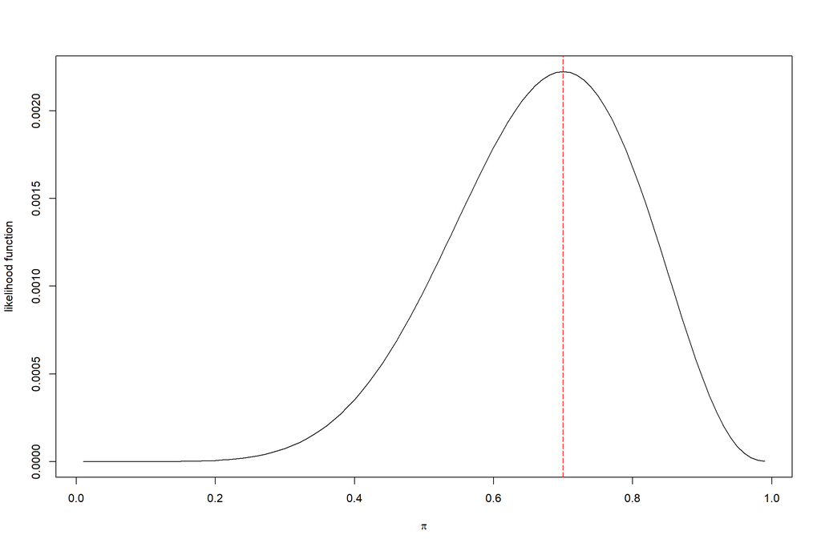

```r
> plot(pi,likFunc(x,n,pi), type="l", xlab=expression(pi),
+      ylab="likelihood function")
> abline(v=x/n, lty=5, col="red")
```

Plot the log-likelihood function $\log(L(\pi \mid x,n))$

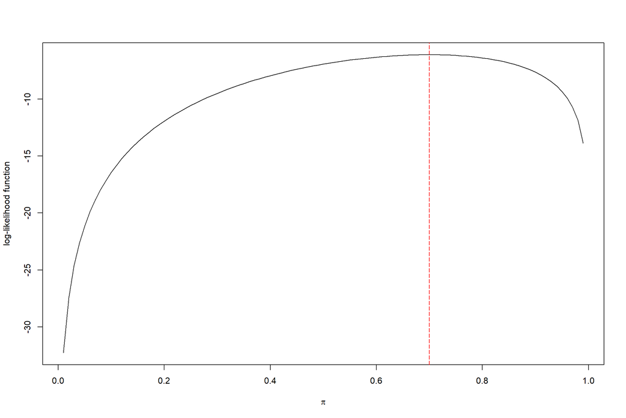

```r
> plot(pi,log(likFunc(x,n,pi)), type="l", xlab=expression(pi),
+      ylab="log-likelihood function")
> abline(v=x/n, lty=5, col="red")
```

The numerical solution for $\hat{\pi} = \frac{x}{n}$ The log-likelihood function is:
$$\log(L(\pi)) \stackrel{\rm def}{=}
\log(\pi^x \cdot (1-\pi)^{n-x}) = x \cdot \log \pi + (n-x) \cdot \log (1-\pi)$$

Its first derivative becomes:
$$\frac{d \log(L(\pi))}{d \pi} = \frac{x}{\pi} + \frac{n-x}{1-\pi} \cdot -1 = \frac{x}{\pi} - \frac{n-x}{1-\pi}$$

Setting the first derivative equal to zero gives the desired estimator = :
$$\frac{x}{\pi} - \frac{n-x}{1-\pi} = 0 \Rightarrow \hat{\pi} = \frac{x}{n}$$

# 2 Heteroscedasticity

## 2.1 Read data & explore data

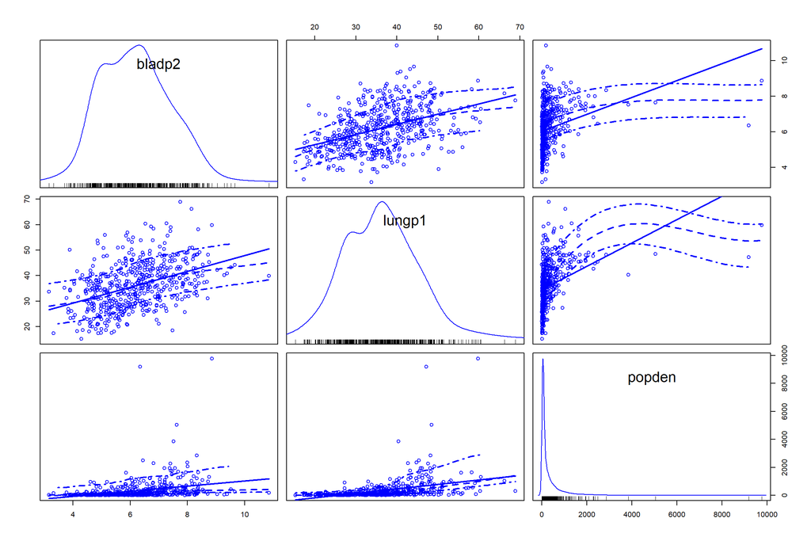

```r
> rm(list=ls())
> library(TexMix)
> setwd("G:\\UTD_Classes\\2020Spring\\GISC7310_AdvancedDataAnalysis\\06Spatial Autocorrelation")
> Bladder <- foreign::read.spss("bladder_wmp2.sav",to.data.frame=TRUE)
>
> car::scatterplotMatrix(~bladp2+lungp1+popden, data=Bladder)
```

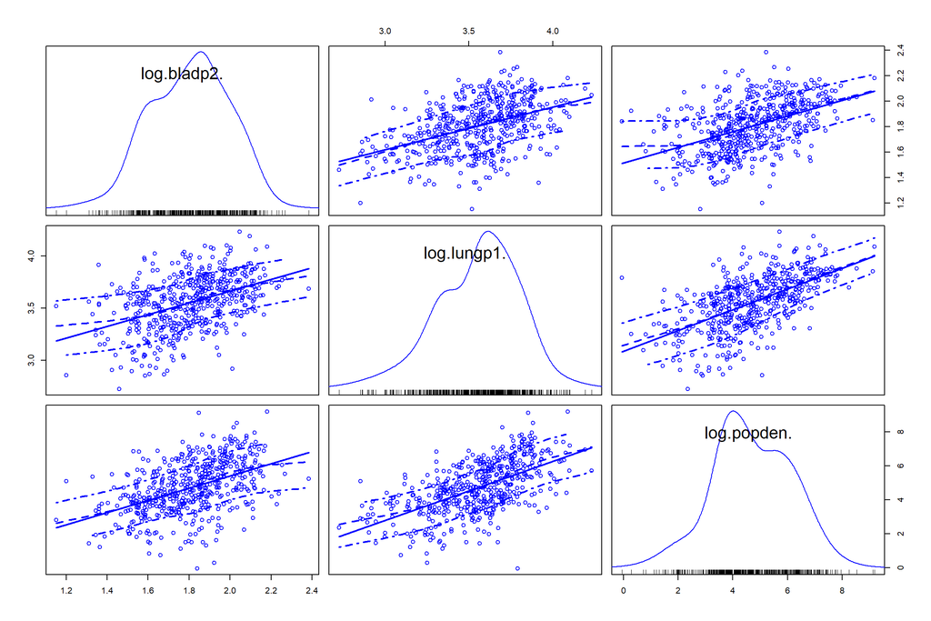

```r
> car::scatterplotMatrix(~log(bladp2)+log(lungp1)+log(popden), data=Bladder)
```

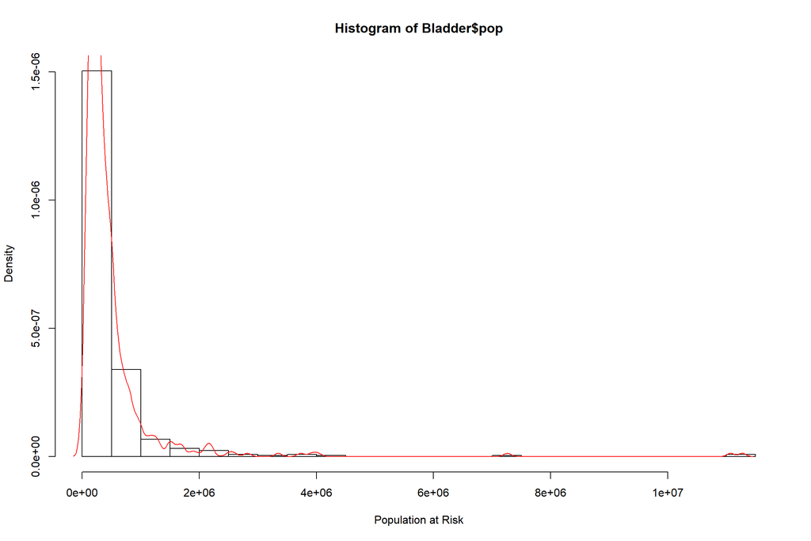

```r
> hist(Bladder$pop, breaks=20, freq=FALSE, xlab="Population at Risk")
> lines(density(Bladder$pop), col="red")
```

Note: these data are *areal aggregates* therefore there will be some *ecological biases* in the model estimates.

## 2.2 Variables description

- The dependent variable `bladp2` measure the age-adjusted male bladder cancer mortality rate per 100.000 population at risk for the 508 US State Economic Areas (SEA) for the period of 1970 to 1994.
- The independent variable `lungp1` is the male lung cancer rate for the period 1950 to 1969. It is a proxy variable for smoking. Smoking is both a risk factor for lung and bladder cancer. Lung cancer has a shorter latency period than bladder cancer. Therefore, the 1950 to 1969 period is used.
- The independent variable `popden` is a proxy variable for behavioral and environmental factors. The populations behavior as well as environmental conditions are different in urban, suburban and rural SEAs.
- The weights variable `pop` is the count of the population at risk in each SEA for the period 1970 to 1994. It varies substantially from SEA to SEA. Thus the SEA’s rates of `bladp2` have different denominators and are expected to have varying variances, which cause heteroscedasticity.

## 2.3 Basic model and heteroscedasticity test

```r
> lmBase <- lm(log(bladp2)~log(lungp1)+log(popden), data=Bladder)
> summary(lmBase)
```

```
R>
R> Call:
R> lm(formula = log(bladp2) ~ log(lungp1) + log(popden), data = Bladder)
R>
R> Residuals:
R>      Min       1Q   Median       3Q      Max
R> -0.56499 -0.11382  0.00918  0.11140  0.53233
R>
R> Coefficients:
R>             Estimate Std. Error t value Pr(>|t|)
R> (Intercept) 0.941258   0.115383   8.158 2.73e-15 ***
R> log(lungp1) 0.185532   0.036541   5.077 5.39e-07 ***
R> log(popden) 0.043155   0.006198   6.962 1.04e-11 ***
R> ---
R> Signif. codes:  0 '***' 0.001 '**' 0.01 '*' 0.05 '.' 0.1 ' ' 1
R>
R> Residual standard error: 0.1733 on 505 degrees of freedom
R> Multiple R-squared:  0.2595, Adjusted R-squared:  0.2566
R> F-statistic: 88.49 on 2 and 505 DF,  p-value: < 2.2e-16
```

```r
> car::ncvTest(lmBase, data=Bladder)
```

```
R> Non-constant Variance Score Test
R> Variance formula: ~ fitted.values
R> Chisquare = 3.732424, Df = 1, p = 0.053366
```

```r
> car::ncvTest(lmBase, var.formula=~log(pop), data=Bladder)
```

```
R> Non-constant Variance Score Test
R> Variance formula: ~ log(pop)
R> Chisquare = 16.21862, Df = 1, p = 5.6437e-05
```

Concurring with epidemiological knowledge, the higher the smoking rate (i.e., `lungp1`) the higher the bladder cancer rate. More densely populated SEA’s have are populated the higher the bladder cancer rate.

The Breusch-Pagan test `car::ncvTest` preforms a score test of the hypothesis of constant error variance against the alternatives [a] that the error variance changes with the level of the fitted values (first test), or [b] with a linear combination of predictors (second test). Notice that the weights variable in the second test is entered log-transformed.

- The unspecific test without an explicit heteroscedasticity model is borderline significant.
- In contrast, assuming that the error variance is a function of the underlying population at risk is highly significant.

## 2.4 Underlying idea of model calibration

See Kleiber & Zeileis pp 76-78 “Weighted Least Squares”. At the first step, use the model

$$\log{\hat{\sigma}_i^2}={\tt fitted}(\log{\epsilon_i^2} \sim \log pop_i)$$

to predict the heteroscedastic error variance. In a subsequent step use the inverse variance $w_i=\frac{1}{\exp(\hat{\sigma}_i^2)}$ as weight in an updated regression $y \sim x_1+x_2+ \cdots +x_k, {\tt weight}=w_i$. Note: This way observations with higher uncertainty are down-weighted. It is possible to iterate.

```r
> auxreg <- lm(log(residuals(lmBase)^2)~log(Bladder$pop))
> summary(auxreg)
```

```
R>
R> Call:
R> lm(formula = log(residuals(lmBase)^2) ~ log(Bladder$pop))
R>
R> Residuals:
R>      Min       1Q   Median       3Q      Max
R> -15.8322  -1.0073   0.4959   1.6622   3.7250
R>
R> Coefficients:
R>                  Estimate Std. Error t value Pr(>|t|)
R> (Intercept)        0.5011     1.5274   0.328 0.743005
R> log(Bladder$pop)  -0.4246     0.1207  -3.518 0.000474 ***
R> ---
R> Signif. codes:  0 '***' 0.001 '**' 0.01 '*' 0.05 '.' 0.1 ' ' 1
R>
R> Residual standard error: 2.358 on 506 degrees of freedom
R> Multiple R-squared:  0.02388,    Adjusted R-squared:  0.02195
R> F-statistic: 12.38 on 1 and 506 DF,  p-value: 0.0004738
```

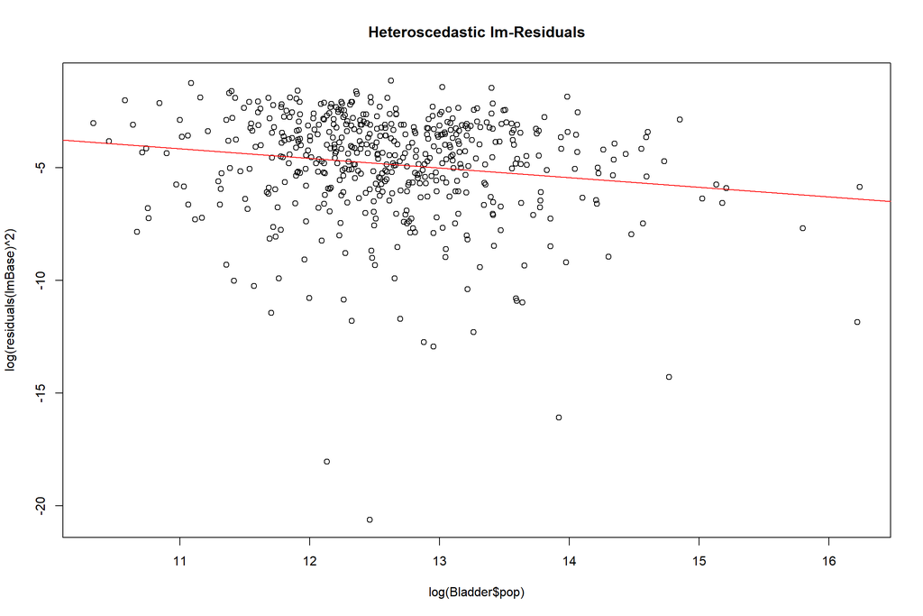

```r
> plot(log(residuals(lmBase)^2)~log(Bladder$pop)); abline(auxreg, col="red")
> title("Heteroscedastic lm-Residuals")
```

```r
> ## Weighted Regression
> predLogSigma2 <- fitted(auxreg)
> lmUpdated <- update(lmBase, weights=1/exp(predLogSigma2))
> summary(lmUpdated)
```

```
R>
R> Call:
R> lm(formula = log(bladp2) ~ log(lungp1) + log(popden), data = Bladder,
R>     weights = 1/exp(predLogSigma2))
R>
R> Weighted Residuals:
R>     Min      1Q  Median      3Q     Max
R> -6.4471 -1.2813  0.1356  1.2982  4.6998
R>
R> Coefficients:
R>             Estimate Std. Error t value Pr(>|t|)
R> (Intercept) 0.876799   0.113387   7.733 5.74e-14 ***
R> log(lungp1) 0.207043   0.035764   5.789 1.24e-08 ***
R> log(popden) 0.040045   0.005739   6.977 9.48e-12 ***
R> ---
R> Signif. codes:  0 '***' 0.001 '**' 0.01 '*' 0.05 '.' 0.1 ' ' 1
R>
R> Residual standard error: 1.932 on 505 degrees of freedom
R> Multiple R-squared:  0.292,  Adjusted R-squared:  0.2892
R> F-statistic: 104.1 on 2 and 505 DF,  p-value: < 2.2e-16
```

## 2.5 Use `lmHetero()` to model Heteroscedasticity

To account for heteroscedasticity related to `log(pop)` the `lmHetero` function in the package `TexMix` can be used. See its online help on how to call the function and what objects it returns.

```r
> lmH1 <- lmHetero(lnbladd~lnlung1+lnpopden | log(pop), data=Bladder)
> summary(lmH1)                         # coefficients of lmH1 and lmBase are similar
```

```
R>
R> ================================================================
R> Multiplicatively Weighted Heteroscedasticity ML-Regression Model
R> ================================================================
R>
R> Call:
R> lmHetero(formula = lnbladd ~ lnlung1 + lnpopden | log(pop), data = Bladder)
R>
R> Regression Coefficients:
R>              Estimate   Std.Err z-value  Pr(>|z|)
R> (Intercept) 0.8895147 0.1133274  7.8491 4.219e-15 ***
R> lnlung1     0.2027807 0.0357727  5.6686 1.440e-08 ***
R> lnpopden    0.0406583 0.0058077  7.0007 2.547e-12 ***
R> ---
R> Signif. codes:  0 '***' 0.001 '**' 0.01 '*' 0.05 '.' 0.1 ' ' 1
R>
R> Gamma Coefficients:
R>                 Gamma   Std.Err z-value  Pr(>|z|)
R> (Intercept)  0.866053  0.916155  0.9453    0.3445
R> log(pop)    -0.349758  0.072383 -4.8321 1.351e-06 ***
R> ---
R> Signif. codes:  0 '***' 0.001 '**' 0.01 '*' 0.05 '.' 0.1 ' ' 1
R>
R> log-likelihood = 181.0003
R>
R> Heteroscedasticity likelihood ratio test:
R>        LR   df  Pr(Chi > LR)
R>  19.62507    1  9.422455e-06
```

```r
> # names(lmH1)
```

Compared to the OLS model the estimated regression coefficients have not changed substantially because even under heteroscedasticity the OLS coefficients are unbiased. However, their standard errors will change.

The `gamma coefficient` of `log(pop)` is *negative* and significant. Thus with an increasing population at risk $n_i$, as suggested by theory, the error variance $\sigma_i^2$ shrinks:
$$\sigma_i^2 \sim \frac{1}{n_i}$$

The likelihood ratio test indicates that, compared to the log-likelihood of the plain OLS model, the log-likelihood of the adjusted model is *significantly* larger.

The `lmHetero( )` returns also a vector of case weights, which can be use in the standard `lm( )` function. This allows to perform the standard model diagnostics of the OLS model. The estimated regression coefficients are identical to those of the `lmHetero` model. The residuals obtained with the function `weighted.residuals( )` are free of heteroscedasticity with respect to the weights variable.

```r
> ## Once weights are estimated, diagnositcs could proceed with lm() and the weights-option
> wlm1 <- lm(log(bladp2)~log(lungp1)+log(popden), data=Bladder, weights=lmH1$weights)
> summary(wlm1)                         # Results of lmH1 and wlm1 are identical
```

```
R>
R> Call:
R> lm(formula = log(bladp2) ~ log(lungp1) + log(popden), data = Bladder,
R>     weights = lmH1$weights)
R>
R> Weighted Residuals:
R>     Min      1Q  Median      3Q     Max
R> -3.3463 -0.6636  0.0677  0.6663  2.4707
R>
R> Coefficients:
R>             Estimate Std. Error t value Pr(>|t|)
R> (Intercept) 0.889518   0.113664   7.826 2.98e-14 ***
R> log(lungp1) 0.202780   0.035879   5.652 2.66e-08 ***
R> log(popden) 0.040658   0.005825   6.980 9.32e-12 ***
R> ---
R> Signif. codes:  0 '***' 0.001 '**' 0.01 '*' 0.05 '.' 0.1 ' ' 1
R>
R> Residual standard error: 1.003 on 505 degrees of freedom
R> Multiple R-squared:  0.2854, Adjusted R-squared:  0.2826
R> F-statistic: 100.9 on 2 and 505 DF,  p-value: < 2.2e-16
```

```r
> wResid <- weighted.residuals(wlm1)    # Function to adjust residuals for heteroscedasticity
```

The example shows how a linear combination of several weights variables can be used.

```r
> ##
> ## Model with quadratic weights structure
> ##
> lmH2 <- lmHetero(log(bladp2)~log(lungp1)+log(popden) | log(pop)+I(log(pop)^2), data=Bladder)
> summary(lmH2)
```

```
R>
R> ================================================================
R> Multiplicatively Weighted Heteroscedasticity ML-Regression Model
R> ================================================================
R>
R> Call:
R> lmHetero(formula = log(bladp2) ~ log(lungp1) + log(popden) |
R>     log(pop) + I(log(pop)^2), data = Bladder)
R>
R> Regression Coefficients:
R>              Estimate   Std.Err z-value  Pr(>|z|)
R> (Intercept) 0.8839357 0.1138092  7.7668 7.994e-15 ***
R> log(lungp1) 0.2056273 0.0359429  5.7209 1.059e-08 ***
R> log(popden) 0.0396237 0.0055551  7.1328 9.832e-13 ***
R> ---
R> Signif. codes:  0 '***' 0.001 '**' 0.01 '*' 0.05 '.' 0.1 ' ' 1
R>
R> Gamma Coefficients:
R>                    Gamma    Std.Err z-value Pr(>|z|)
R> (Intercept)   -13.414521   8.002140 -1.6764  0.09367 .
R> log(pop)        1.902019   1.243728  1.5293  0.12619
R> I(log(pop)^2)  -0.088375   0.048245 -1.8318  0.06698 .
R> ---
R> Signif. codes:  0 '***' 0.001 '**' 0.01 '*' 0.05 '.' 0.1 ' ' 1
R>
R> log-likelihood = 182.1035
R>
R> Heteroscedasticity likelihood ratio test:
R>        LR   df  Pr(Chi > LR)
R>  21.83149    2   1.81699e-05
```

```r
> ##
> ## Manual LR-Test: Quadratic versus linear weights structue
> ##
> (chi <- -2*(lmH1$logLikeH1-lmH2$logLikeH1))
```

```
R> [1] 2.206415
```

```r
> (pchisq(chi,df=1, lower.tail=F))
```

```
R> [1] 0.1374377
```

The manual likelihood ratio test compares the model with `| log(pop)` against the augmented model `| log(pop)+I(log(pop)^2`. In this case, there is no significant improvement using the augmented model and its `Gamma Coefficients` are no longer significant.

# 3 Spatial Autocorrelation

## 3.1 Import data

```r
> rm(list=ls(all=TRUE))
> library(car); library(maptools); library(spdep); library(TexMix)
> ##
> ## Read Poly Shapefiles (readShapePoly in library maptools)
> ##
> setwd('./Italy')
> getinfo.shape("Provinces.shp")
```

```
R> Shapefile type: Polygon, (5), # of Shapes: 95
```

```r
> neig.shp <- rgdal::readOGR(dsn=getwd(), layer="Neighbors", integer64="warn.loss")
```

```
R> OGR data source with driver: ESRI Shapefile
R> Source: "G:\UTD_Classes\2020Spring\GISC7310_AdvancedDataAnalysis\06Spatial Autocorrelation\Italy", layer: "Neighbors"
R> with 19 features
R> It has 3 fields
R> Integer64 fields read as signed 32-bit integers:  ID
```

```r
> prov.shp <- rgdal::readOGR(dsn=getwd(), layer="Provinces", integer64="warn.loss")
```

```
R> OGR data source with driver: ESRI Shapefile
R> Source: "G:\UTD_Classes\2020Spring\GISC7310_AdvancedDataAnalysis\06Spatial Autocorrelation\Italy", layer: "Provinces"
R> with 95 features
R> It has 17 fields
R> Integer64 fields read as signed 32-bit integers:  ID LATCTRD LONGCTRD MALEPOP94 FEMPOP94 TOTPOP94
```

```r
> summary(prov.shp)
```

```
R> Object of class SpatialPolygonsDataFrame
R> Coordinates:
R>         min      max
R> x  6.614898 18.52305
R> y 35.490752 47.09521
R> Is projected: FALSE
R> proj4string :
R> [+proj=longlat +datum=WGS84 +no_defs +ellps=WGS84 +towgs84=0,0,0]
R> Data attributes:
R>        ID            AREA          PROVID        LATCTRD
R>  Min.   : 1.0   Min.   : 206   Min.   : 1.0   Min.   :36906749
R>  1st Qu.:24.5   1st Qu.:2078   1st Qu.:24.5   1st Qu.:40980025
R>  Median :48.0   Median :2754   Median :48.0   Median :43503625
R>  Mean   :48.0   Mean   :3169   Mean   :48.0   Mean   :42881681
R>  3rd Qu.:71.5   3rd Qu.:3653   3rd Qu.:71.5   3rd Qu.:45115874
R>  Max.   :95.0   Max.   :7523   Max.   :95.0   Max.   :46698170
R>
R>     LONGCTRD        PROVNAME              REGION     RURURB     MALEPOP94
R>  Min.   : 7385709   Forl\xec   : 1   Central :30   rural:86   Min.   :  44993
R>  1st Qu.:10028960   Agrigento  : 1   North   :30   urban: 9   1st Qu.: 135793
R>  Median :12133226   Alessandria: 1   Sardinia: 4              Median : 200644
R>  Mean   :12150462   Ancona     : 1   Sicily  : 9              Mean   : 292534
R>  3rd Qu.:14029612   Aosta      : 1   South   :22              3rd Qu.: 367072
R>  Max.   :18178062   Arezzo     : 1                            Max.   :1886479
R>                     (Other)    :89
R>     FEMPOP94          TOTPOP94         POPDENSITY       TOTFERTRAT
R>  Min.   :  47333   Min.   :  92326   Min.   :  35.2   Min.   :0.79
R>  1st Qu.: 145345   1st Qu.: 283187   1st Qu.: 106.5   1st Qu.:1.00
R>  Median : 213233   Median : 413577   Median : 165.9   Median :1.12
R>  Mean   : 310293   Mean   : 602827   Mean   : 235.5   Mean   :1.18
R>  3rd Qu.: 379673   3rd Qu.: 748658   3rd Qu.: 246.9   3rd Qu.:1.35
R>  Max.   :2028089   Max.   :3914568   Max.   :2620.1   Max.   :1.73
R>
R>    FEMMARAGE       DIVORCERAT       ILLITERRAT      TELEPERFAM
R>  Min.   :24.62   Min.   :0.0500   Min.   :0.240   Min.   :0.4585
R>  1st Qu.:26.18   1st Qu.:0.2150   1st Qu.:0.715   1st Qu.:0.7327
R>  Median :26.93   Median :0.3900   Median :1.580   Median :0.7907
R>  Mean   :26.72   Mean   :0.4395   Mean   :2.292   Mean   :0.7666
R>  3rd Qu.:27.25   3rd Qu.:0.6600   3rd Qu.:3.505   3rd Qu.:0.8241
R>  Max.   :28.42   Max.   :1.0600   Max.   :7.420   Max.   :0.8919
R>
```

```r
> proj4string(prov.shp)                                    # map projection
```

```
R> [1] "+proj=longlat +datum=WGS84 +no_defs +ellps=WGS84 +towgs84=0,0,0"
```

```r
> prov.centroid <- coordinates(prov.shp)                   # Get province centroids
> prov.bbox <- bbox(prov.shp)                              # province bounding box for map region
```

Qualitative map theme of `REGION`

```r
> table(prov.shp$REGION)
```

```
R>
R>  Central    North Sardinia   Sicily    South
R>       30       30        4        9       22
```

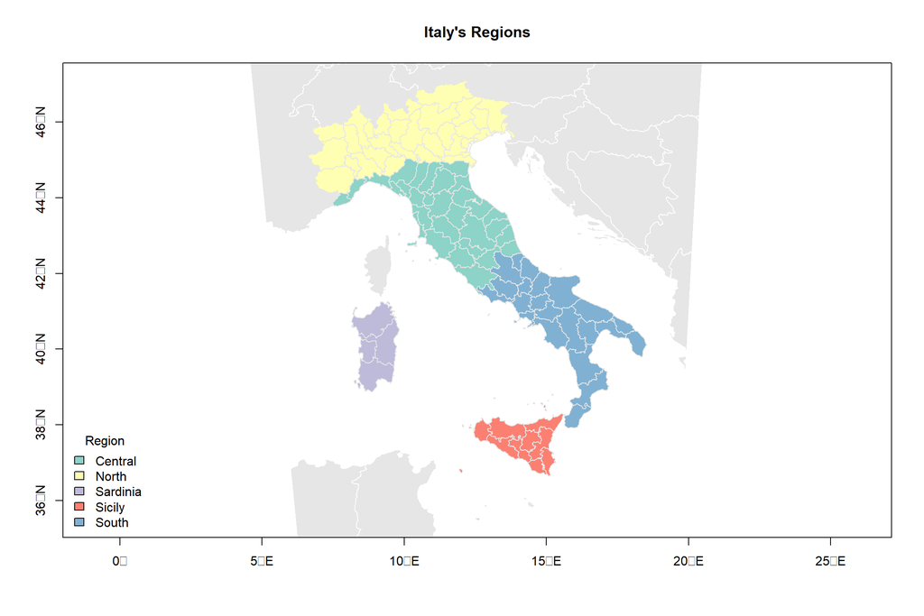

```r
> plot(neig.shp,axes=T,col=grey(0.9), border="white",      # background: neighboring countries
+      xlim=prov.bbox[1,], ylim=prov.bbox[2,])
> mapColorQual(prov.shp$REGION, prov.shp, map.title="Italy's Regions",
+                           legend.title="Region", add.to.map=T)
```

Gradient map theme of `TOTFERTRAT`

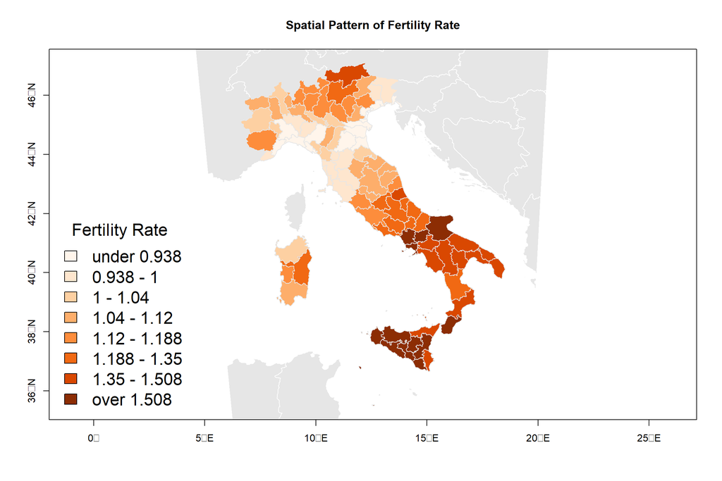

```r
> plot(neig.shp,axes=T,col=grey(0.9),border="white",       # first background (axes=T adds lat/long frame)
+      xlim=prov.bbox[1,],ylim=prov.bbox[2,])              # within bounding box
> mapColorRamp(prov.shp$TOTFERTRAT, prov.shp, breaks=8,    # second add map
+               map.title="Spatial Pattern of Fertility Rate",
+               legend.title="Fertility Rate",
+               legend.cex=1.7, add.to.map=T)
```

## 3.3 Basic regression model

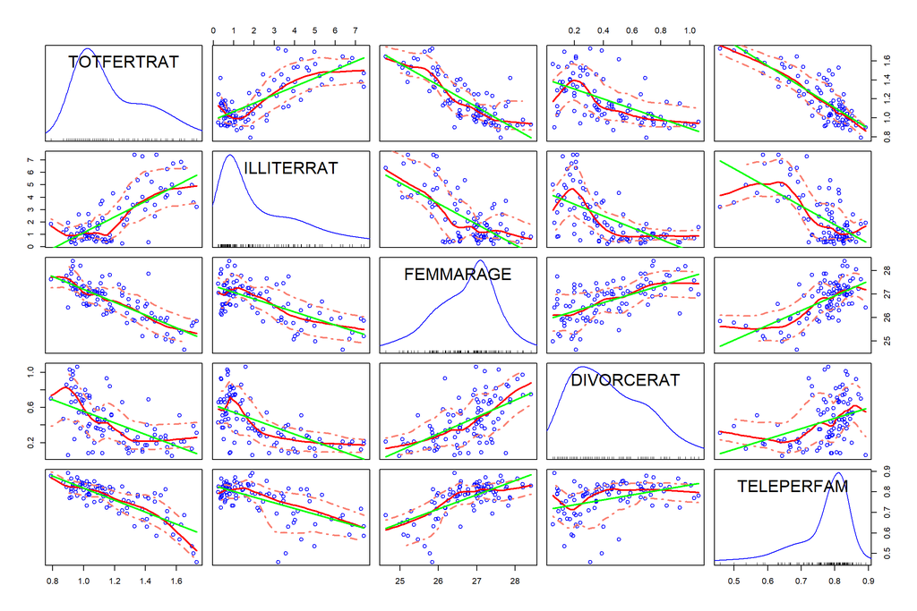

```r
> ## Regression model for fertility including model diagnostics
> scatterplotMatrix(~TOTFERTRAT+ILLITERRAT+FEMMARAGE+DIVORCERAT+TELEPERFAM, data=prov.shp,
+                    smooth=list(span = 0.35, lty.smooth=1, col.smooth="red", col.var="salmon"),
+                    regLine=list(col="green"))
```

```r
> fert.lm <- lm(TOTFERTRAT~ILLITERRAT+FEMMARAGE+DIVORCERAT+TELEPERFAM, data=prov.shp)
> summary(fert.lm,corr=F)
```

```
R>
R> Call:
R> lm(formula = TOTFERTRAT ~ ILLITERRAT + FEMMARAGE + DIVORCERAT +
R>     TELEPERFAM, data = prov.shp)
R>
R> Residuals:
R>      Min       1Q   Median       3Q      Max
R> -0.21906 -0.06267 -0.00966  0.05425  0.41272
R>
R> Coefficients:
R>              Estimate Std. Error t value Pr(>|t|)
R> (Intercept)  4.496337   0.513726   8.752 1.13e-13 ***
R> ILLITERRAT   0.020377   0.008735   2.333   0.0219 *
R> FEMMARAGE   -0.088837   0.020771  -4.277 4.71e-05 ***
R> DIVORCERAT  -0.112265   0.055648  -2.017   0.0466 *
R> TELEPERFAM  -1.226364   0.183037  -6.700 1.76e-09 ***
R> ---
R> Signif. codes:  0 '***' 0.001 '**' 0.01 '*' 0.05 '.' 0.1 ' ' 1
R>
R> Residual standard error: 0.1035 on 90 degrees of freedom
R> Multiple R-squared:  0.8096, Adjusted R-squared:  0.8012
R> F-statistic: 95.69 on 4 and 90 DF,  p-value: < 2.2e-16
```

```r
> vif(fert.lm)
```

```
R> ILLITERRAT  FEMMARAGE DIVORCERAT TELEPERFAM
R>   2.601115   2.468365   1.855334   2.088907
```

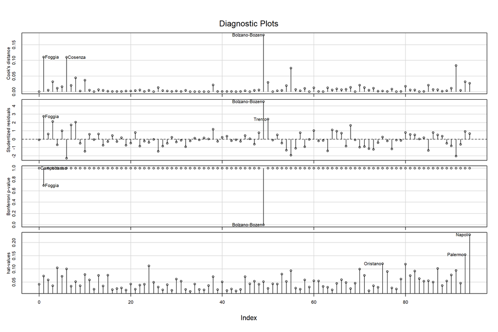

```r
> # Perform Residual Diagnostics
> influenceIndexPlot(fert.lm, id=list(n=3,labels=prov.shp$PROVNAME))
```

```r
> fertResid <- residuals(fert.lm)
```

## 3.4 Identify potential outlier

```r
> ## Why is Bolzano-Bozen an extreme observation? Shall we delete it?
> idx.max <- which.max(abs(fertResid))        # Get index of a record with "outlying" observation
>
> ## Map potential outlier
> extremeObs <- rep(0, length(fertResid))
> extremeObs[idx.max] <- 1
> extremeObs <- factor(extremeObs, labels=c("Population","Outlier"))
> table(extremeObs)
```

```
R> extremeObs
R> Population    Outlier
R>         94          1
```

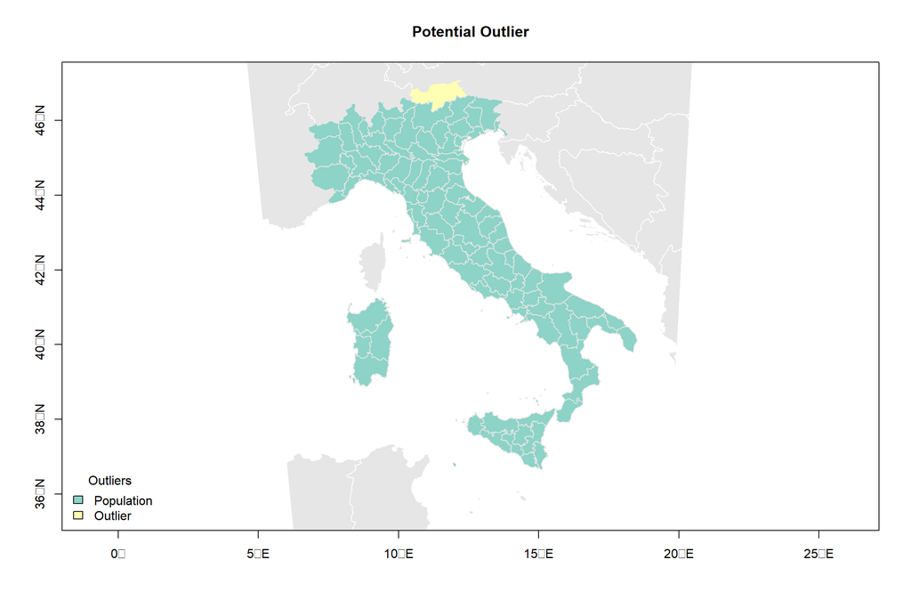

```r
> plot(neig.shp,axes=T,col=grey(0.9),border="white",                 # background: neighboring countries
+      xlim=prov.bbox[1,],ylim=prov.bbox[2,])
> mapColorQual(extremeObs, prov.shp, map.title="Potential Outlier",
+               legend.title="Outliers", add.to.map=T)
```

```r
> ## Inspect outlier
> prov.shp@data[idx.max,]                      # List info of record centre is outlier
```

```
R>    ID     AREA PROVID  LATCTRD LONGCTRD      PROVNAME REGION RURURB MALEPOP94
R> 49 50 7466.006     21 46698170 11414936 Bolzano-Bozen  North  rural    220787
R>    FEMPOP94 TOTPOP94 POPDENSITY TOTFERTRAT FEMMARAGE DIVORCERAT ILLITERRAT
R> 49   228268   449055   60.14662       1.42     27.88       0.69       0.35
R>    TELEPERFAM
R> 49    0.76808
```

```r
> ## Delete outlier or update information
> #prov.shp <- prov.shp[-idx.max ]             # Delete extreme observation from shapefile
> prov.shp@data[idx.max, "TOTFERTRAT"] <- 1.2  # Or change its value within the shapefile
>
> ## Continue with updated dataset
> fert.lm <- lm(TOTFERTRAT~ILLITERRAT+FEMMARAGE+DIVORCERAT+TELEPERFAM,data=prov.shp) # update model
> summary(fert.lm)
```

```
R>
R> Call:
R> lm(formula = TOTFERTRAT ~ ILLITERRAT + FEMMARAGE + DIVORCERAT +
R>     TELEPERFAM, data = prov.shp)
R>
R> Residuals:
R>       Min        1Q    Median        3Q       Max
R> -0.219546 -0.059570 -0.008288  0.055215  0.256479
R>
R> Coefficients:
R>              Estimate Std. Error t value Pr(>|t|)
R> (Intercept)  4.625004   0.476205   9.712 1.13e-15 ***
R> ILLITERRAT   0.021280   0.008097   2.628   0.0101 *
R> FEMMARAGE   -0.095354   0.019254  -4.953 3.41e-06 ***
R> DIVORCERAT  -0.111163   0.051584  -2.155   0.0338 *
R> TELEPERFAM  -1.173424   0.169668  -6.916 6.54e-10 ***
R> ---
R> Signif. codes:  0 '***' 0.001 '**' 0.01 '*' 0.05 '.' 0.1 ' ' 1
R>
R> Residual standard error: 0.09594 on 90 degrees of freedom
R> Multiple R-squared:  0.8345, Adjusted R-squared:  0.8272
R> F-statistic: 113.5 on 4 and 90 DF,  p-value: < 2.2e-16
```

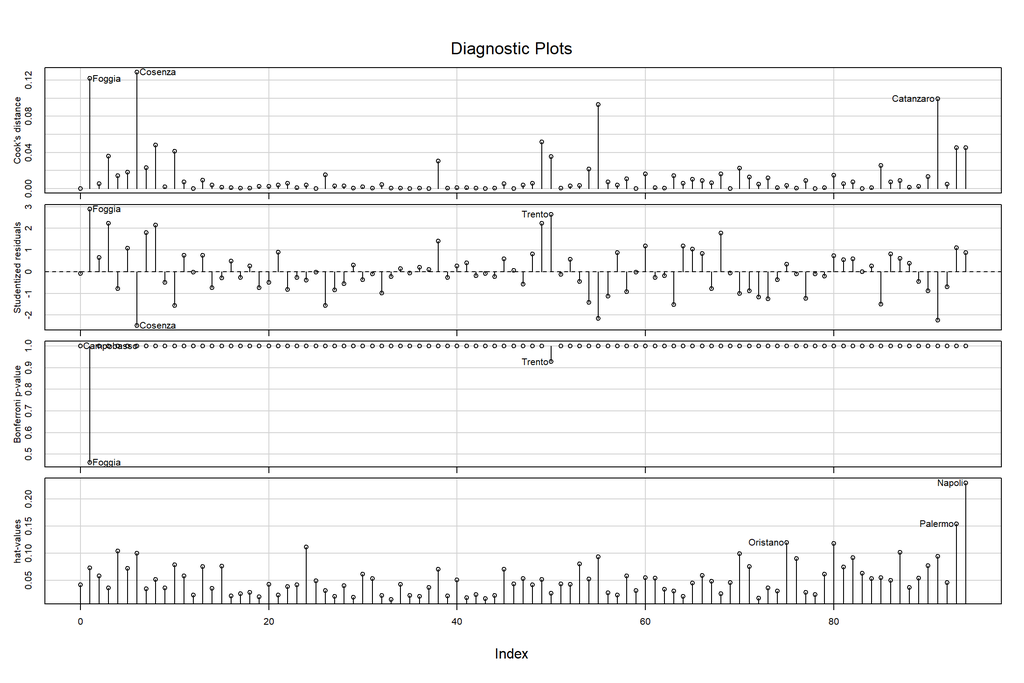

```r
> influenceIndexPlot(fert.lm, id=list(n=3, labels=prov.shp$PROVNAME))
```

## 3.5 Check for heteroscedasticity

```r
> ## Check for heteroscedasticity
> fert.fgls <- lmHetero(TOTFERTRAT~ILLITERRAT+FEMMARAGE+DIVORCERAT+TELEPERFAM | log(FEMPOP94),
+                       data=prov.shp)
> summary(fert.fgls)
```

```
R>
R> ================================================================
R> Multiplicatively Weighted Heteroscedasticity ML-Regression Model
R> ================================================================
R>
R> Call:
R> lmHetero(formula = TOTFERTRAT ~ ILLITERRAT + FEMMARAGE + DIVORCERAT +
R>     TELEPERFAM | log(FEMPOP94), data = prov.shp)
R>
R> Regression Coefficients:
R>               Estimate    Std.Err z-value  Pr(>|z|)
R> (Intercept)  4.3881835  0.4265870 10.2867 < 2.2e-16 ***
R> ILLITERRAT   0.0286213  0.0074558  3.8388 0.0001236 ***
R> FEMMARAGE   -0.0894065  0.0174198 -5.1325 2.860e-07 ***
R> DIVORCERAT  -0.1073668  0.0441414 -2.4323 0.0150017 *
R> TELEPERFAM  -1.1055990  0.1775114 -6.2283 4.714e-10 ***
R> ---
R> Signif. codes:  0 '***' 0.001 '**' 0.01 '*' 0.05 '.' 0.1 ' ' 1
R>
R> Gamma Coefficients:
R>                   Gamma   Std.Err z-value  Pr(>|z|)
R> (Intercept)   -12.60936   2.56690 -4.9123 9.001e-07 ***
R> log(FEMPOP94)   0.63263   0.20748  3.0492  0.002295 **
R> ---
R> Signif. codes:  0 '***' 0.001 '**' 0.01 '*' 0.05 '.' 0.1 ' ' 1
R>
R> log-likelihood = 92.96326
R>
R> Heteroscedasticity likelihood ratio test:
R>        LR   df  Pr(Chi > LR)
R>  5.019431    1    0.02506441
```

Note the possitive sign of $\gamma_2$ is contradicting theory. This is marginal significant of the heteroscedastic model and will be used subsequently for demonstration purposes.

Therefore, the lm-model is updated to a weighted lm-model.

```r
> fert.wlm <- lm(TOTFERTRAT~ILLITERRAT+FEMMARAGE+DIVORCERAT+TELEPERFAM, data=prov.shp,
+                weights=fert.fgls$weights)
> summary(fert.wlm)
```

```
R>
R> Call:
R> lm(formula = TOTFERTRAT ~ ILLITERRAT + FEMMARAGE + DIVORCERAT +
R>     TELEPERFAM, data = prov.shp, weights = fert.fgls$weights)
R>
R> Weighted Residuals:
R>      Min       1Q   Median       3Q      Max
R> -2.51018 -0.61717  0.02056  0.60411  2.81691
R>
R> Coefficients:
R>             Estimate Std. Error t value Pr(>|t|)
R> (Intercept)  4.38815    0.43827  10.012 2.69e-16 ***
R> ILLITERRAT   0.02862    0.00766   3.737 0.000327 ***
R> FEMMARAGE   -0.08941    0.01790  -4.996 2.86e-06 ***
R> DIVORCERAT  -0.10737    0.04535  -2.367 0.020052 *
R> TELEPERFAM  -1.10560    0.18238  -6.062 3.09e-08 ***
R> ---
R> Signif. codes:  0 '***' 0.001 '**' 0.01 '*' 0.05 '.' 0.1 ' ' 1
R>
R> Residual standard error: 1.027 on 90 degrees of freedom
R> Multiple R-squared:  0.8419, Adjusted R-squared:  0.8348
R> F-statistic: 119.8 on 4 and 90 DF,  p-value: < 2.2e-16
```

## 3.6 Map the regression residual

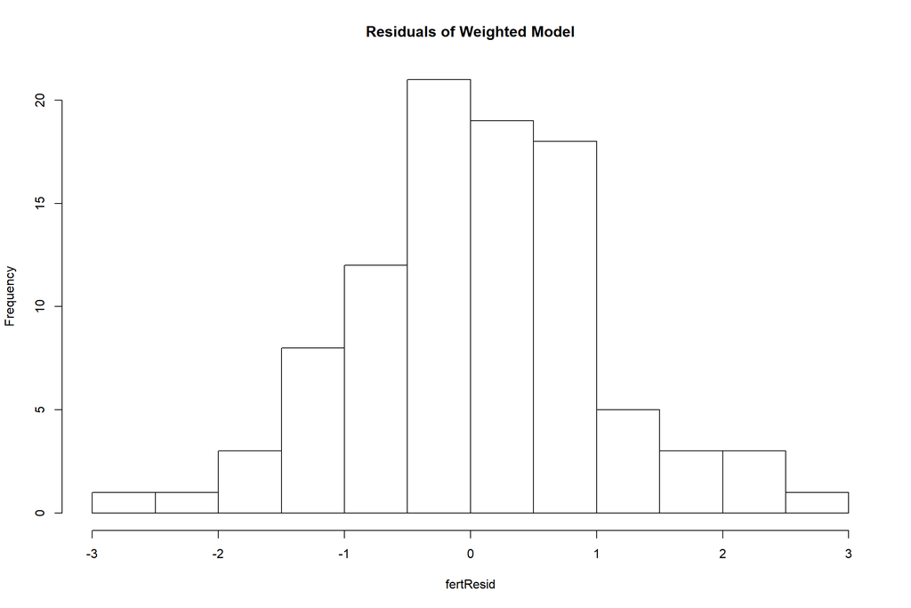

```r
> ## Plot Regression Residuals (Bi-polar)
> fertResid <- weighted.residuals(fert.wlm)                # Update residuals
> hist(fertResid, main="Residuals of Weighted Model")      # Explore distribution to
```

```r
> length(fertResid[fertResid < 0])                         # identify number of pos/neg classes
```

```
R> [1] 46
```

```r
> length(fertResid[fertResid >= 0])
```

```
R> [1] 49
```

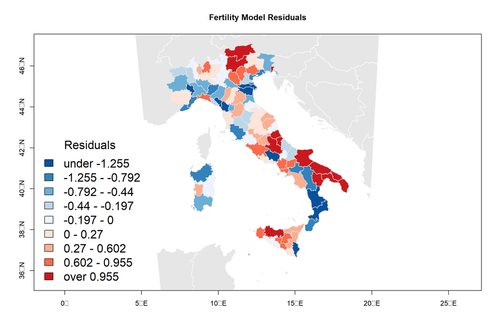

```r
> plot(neig.shp,axes=T,col=grey(0.9),border="white",
+      xlim=prov.bbox[1,],ylim=prov.bbox[2,])               # first background
> mapBiPolar(fertResid, prov.shp,                           # second regression residuals
+             neg.breaks=5, pos.breaks=4, break.value=0.0,
+             map.title="Fertility Model Residuals",
+             legend.title="Residuals",
+             legend.cex=1.7, add.to.map=T)
```

The map pattern indicates that there are spatial clusters with positive and negative regression residuals. Thus the independence assumption is violated.

## 3.7 Identify the linkage structure

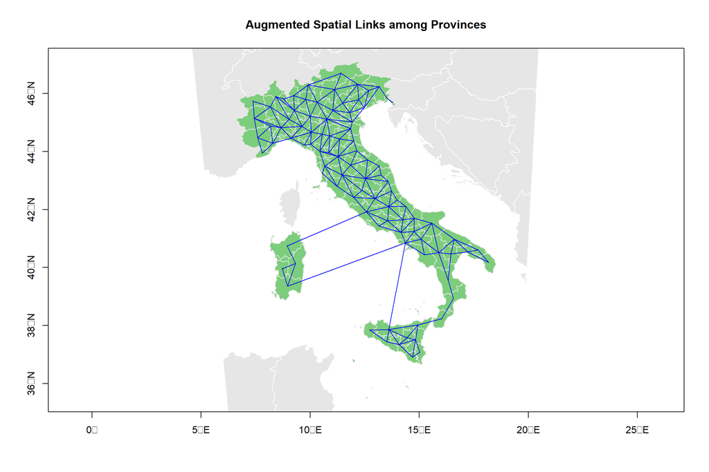

```r
> ## Plot Augmented Spatial Links among Italian Provinces
> ## Notes: Shape file has been edited so satellite islands are connected to mainland
> ## Alternatively spdep::edit.nb function (does not work with RStudio)
> prov.link <- poly2nb(prov.shp, queen=F)                          # Generate neighbors links
>
> plot(neig.shp,axes=T,col=grey(0.9),border="white",
+      xlim=prov.bbox[1,],ylim=prov.bbox[2,])                      # First background
> plot(prov.shp,col="palegreen3" ,border=grey(0.9), axes=T, add=T) # Second plot areas
> plot(prov.link,coords=prov.centroid, pch=19, cex=0.1,            # Third plot links focused at centroids
+      col="blue", add=T)
> title("Augmented Spatial Links among Provinces")                 # Forth add title
> box()                                                            # Fifth refresh frame
```

## 3.8 Perform a test for spatial autocorrelation in the residuals

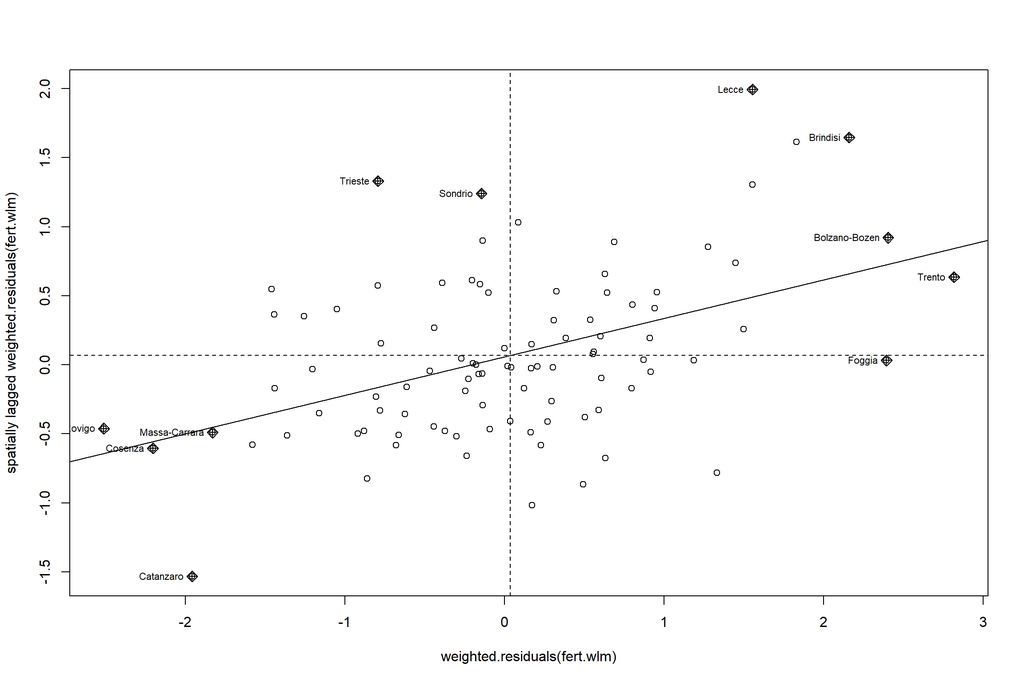

```r
> prov.linkW <- nb2listw(prov.link, style="W")                   # generated row-sum standardized neighbors list
> spOutliers <- moran.plot(weighted.residuals(fert.wlm),         # Moran plot with outlier diagnositics
+                          prov.linkW, labels=prov.shp$PROVNAME)
```

```r
> lm.morantest(fert.wlm, prov.linkW)                             # Test with W-coding scheme
```

```
R>
R>  Global Moran I for regression residuals
R>
R> data:
R> model: lm(formula = TOTFERTRAT ~ ILLITERRAT + FEMMARAGE + DIVORCERAT +
R> TELEPERFAM, data = prov.shp, weights = fert.fgls$weights)
R> weights: prov.linkW
R>
R> Moran I statistic standard deviate = 4.5306, p-value = 2.941e-06
R> alternative hypothesis: greater
R> sample estimates:
R> Observed Moran I      Expectation         Variance
R>      0.281242173     -0.029598120      0.004707174
```

Also look up `help(lm.morantest)`. Internally weighted regression residuals are used.

## 3.9 Maximum likelihood estimation of SAR

Check the online help for the `spdep::spautolm( )` function. Note the use of the `weights` option here. When the `weights` option is used `spautolm` requires a full specification of the model rather than just using the `fert.wlm` object.

```r
> fert.SAR <- spautolm(TOTFERTRAT~ILLITERRAT+FEMMARAGE+DIVORCERAT+TELEPERFAM,
+                      data=prov.shp, weights = fert.fgls$weights,
+                      na.action="na.omit", listw=prov.linkW, family="SAR")
> summary(fert.SAR)
```

```
R>
R> Call: spautolm(formula = TOTFERTRAT ~ ILLITERRAT + FEMMARAGE + DIVORCERAT +
R>     TELEPERFAM, data = prov.shp, listw = prov.linkW, weights = fert.fgls$weights,
R>     na.action = "na.omit", family = "SAR")
R>
R> Residuals:
R>        Min         1Q     Median         3Q        Max
R> -0.1346010 -0.0515529  0.0066078  0.0595509  0.2377229
R>
R> Coefficients:
R>               Estimate Std. Error z value  Pr(>|z|)
R> (Intercept)  3.1164030  0.4694416  6.6385 3.168e-11
R> ILLITERRAT   0.0166445  0.0089083  1.8684  0.061701
R> FEMMARAGE   -0.0484661  0.0178010 -2.7227  0.006476
R> DIVORCERAT  -0.0309038  0.0378188 -0.8172  0.413840
R> TELEPERFAM  -0.9134920  0.1668045 -5.4764 4.340e-08
R>
R> Lambda: 0.76152 LR test value: 23.96 p-value: 9.8382e-07
R> Numerical Hessian standard error of lambda: 0.092528
R>
R> Log likelihood: 104.943
R> ML residual variance (sigma squared): 0.63854, (sigma: 0.79909)
R> Number of observations: 95
R> Number of parameters estimated: 7
R> AIC: -195.89
```

The likelihood ratio test of the SAR model is identically to the hand calculated one. Important here is a slight difference in the calculation when heteroscedasticity is incorporated.

```r
> ## Likelihood Ratio test (identical to LR from spautolm)
> #(likeH0 <- logLik(fert.lm))                     # Use for unweighted model
> likeH0 <- fert.fgls$logLikeH1
> (likeH1 <- logLik(fert.SAR))
```

```
R> Warning: Method logLik.spautolm moved to the spatialreg package
```

```
R> Warning in logLik.spautolm(fert.SAR): install the spatialreg package
```

```
R> 'log Lik.' 104.943 (df=7)
```

```r
> cat("chi-square value:  ", chi <- -2*(likeH0[1]-likeH1[1]))
```

```
R> chi-square value:   23.95954
```

```r
> cat("\nerror-probability: ", pchisq(chi, df=1, lower.tail=F))
```

```
R>
R> error-probability:  9.838169e-07
```

Check whether the residuals are as expected free of spatial autocorrelation. Because the distribution of ML residuals in unknown, Morans’s $I$ is evaluated here using a randomization approach.

```
R> Warning: Method residuals.spautolm moved to the spatialreg package
```

```
R> Warning in residuals.spautolm(fert.SAR): install the spatialreg package
```

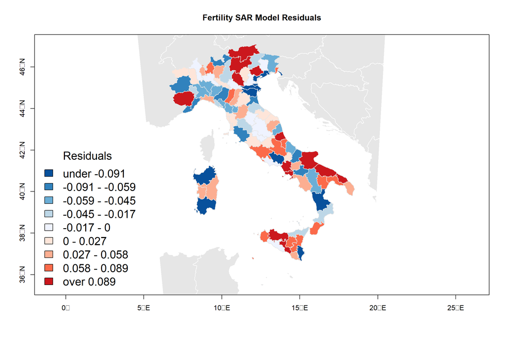

```r
> ## Moran test applying randomization because ML may not be normal distributed
> plot(neig.shp,axes=T,col=grey(0.9),border="white",
+      xlim=prov.bbox[1,],ylim=prov.bbox[2,])                        # first background
> mapBiPolar(residuals(fert.SAR), prov.shp,                          # second regression residuals
+             neg.breaks=5, pos.breaks=4, break.value=0.0,
+             map.title="Fertility SAR Model Residuals",
+             legend.title="Residuals", legend.cex = 1.6,
+             add.to.map=T)
```

```r
> ## Evaluate ML residuals for spatial autocorrelation
> moran.mc(residuals(fert.SAR), prov.linkW, nsim=9999)
```

```
R> Warning: Method residuals.spautolm moved to the spatialreg package

R> Warning: install the spatialreg package
```

```
R>
R>  Monte-Carlo simulation of Moran I
R>
R> data:  residuals(fert.SAR)
R> weights: prov.linkW
R> number of simulations + 1: 10000
R>
R> statistic = -0.060189, observed rank = 2417, p-value = 0.7583
R> alternative hypothesis: greater
```